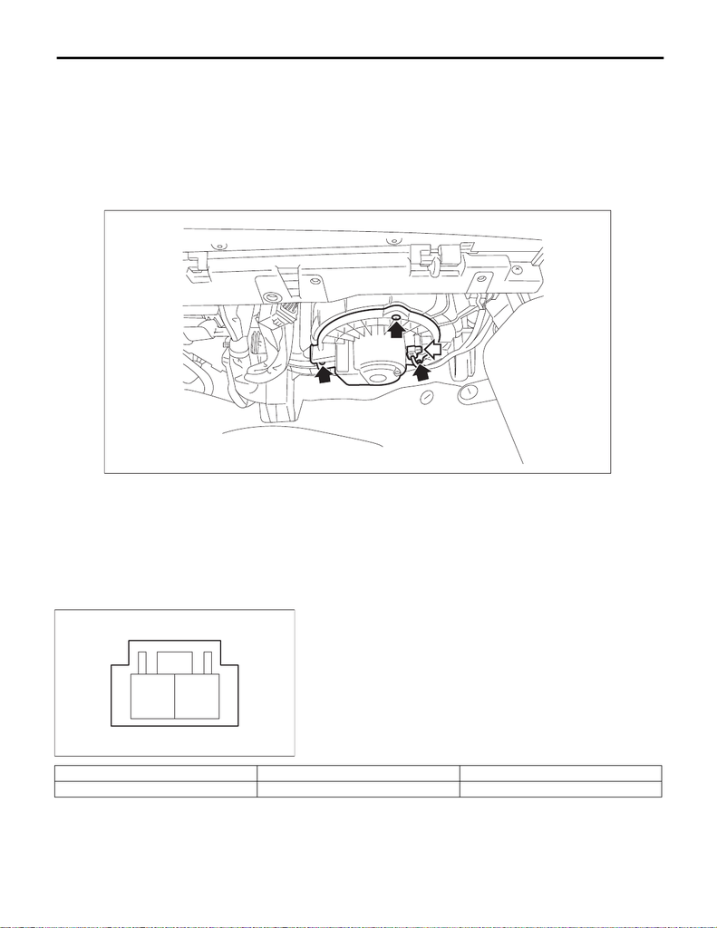

AC-37

Blower Motor

HVAC SYSTEM (HEATER, VENTILATOR AND A/C)

10.Blower Motor

A: REMOVAL

1) Disconnect the ground cable from battery. <Ref. to NT-5, BATTERY, NOTE, Note.>

NOTE:

For models other than STI model, disconnect the ground terminal from battery sensor.

2) Remove the blower - motor.

(1) Disconnect the connector.

(2) Remove the screws and detach the blower - motor.

B: INSTALLATION

1) Install the blower - motor.

2) Connect the battery ground terminal. <Ref. to NT-5, BATTERY, NOTE, Note.>

NOTE:

For models other than STI model, connect the ground terminal to battery sensor.

C: INSPECTION

1) Check the motor operation when battery voltage is applied between the connector terminals.

2) If it does not operate normally, replace the blower - motor.

AC-03432

AC-03523

21

Terminal No. Inspection conditions Specification

2 (+) — 1 (–) Apply battery voltage. Rotation